```python
import pandas as pd
import numpy as np
```

# 1. 데이터 분할

## 1.1 데이터 불러오기

```python
train_df = pd.read_csv("/Users/jaehyunlee/Downloads/주제분석 2주차 패키지/train.csv") # train과 test 불러오기
test_df = pd.read_csv("/Users/jaehyunlee/Downloads/주제분석 2주차 패키지/test.csv")
```

## 1.2 X와 Y 분리

```python
train_df.head() # train이 어떻게 생겼는지 확인
```

|  | dong | apt | exclusive_use_area | floor | price | transaction_year | until_trans | sin_date | cos_date |
| --- | --- | --- | --- | --- | --- | --- | --- | --- | --- |
| 0 | 사직동 | 광화문풍림스페이스본(9-0) | 95.88 | 6 | 70000 | 0 | 5 | -1.000000e+00 | -1.836970e-16 |
| 1 | 사직동 | 광화문풍림스페이스본(9-0) | 108.55 | 11 | 100500 | 0 | 5 | -2.449294e-16 | 1.000000e+00 |
| 2 | 사직동 | 광화문풍림스페이스본(9-0) | 94.51 | 1 | 65800 | 0 | 5 | -2.449294e-16 | 1.000000e+00 |
| 3 | 수송동 | 로얄팰리스스위트 | 42.87 | 8 | 30500 | 0 | 8 | -1.000000e+00 | -1.836970e-16 |
| 4 | 수송동 | 로얄팰리스스위트 | 39.67 | 15 | 30500 | 0 | 8 | 1.000000e+00 | 3.061617e-16 |

```python
train_df
```

|  | dong | apt | exclusive_use_area | floor | price | transaction_year | until_trans | sin_date | cos_date |
| --- | --- | --- | --- | --- | --- | --- | --- | --- | --- |
| 0 | 사직동 | 광화문풍림스페이스본(9-0) | 95.88 | 6 | 70000 | 0 | 5 | -1.000000e+00 | -1.836970e-16 |
| 1 | 사직동 | 광화문풍림스페이스본(9-0) | 108.55 | 11 | 100500 | 0 | 5 | -2.449294e-16 | 1.000000e+00 |
| 2 | 사직동 | 광화문풍림스페이스본(9-0) | 94.51 | 1 | 65800 | 0 | 5 | -2.449294e-16 | 1.000000e+00 |
| 3 | 수송동 | 로얄팰리스스위트 | 42.87 | 8 | 30500 | 0 | 8 | -1.000000e+00 | -1.836970e-16 |
| 4 | 수송동 | 로얄팰리스스위트 | 39.67 | 15 | 30500 | 0 | 8 | 1.000000e+00 | 3.061617e-16 |
| ... | ... | ... | ... | ... | ... | ... | ... | ... | ... |
| 422159 | 강일동 | 강일리버파크2단지 | 84.74 | 6 | 47000 | 4 | 8 | -2.204364e-15 | 1.000000e+00 |
| 422160 | 강일동 | 고덕리엔파크2단지 | 59.83 | 7 | 46500 | 4 | 6 | 1.000000e+00 | 4.892397e-16 |
| 422161 | 강일동 | 강일리버파크5단지 | 59.87 | 1 | 40500 | 4 | 8 | 1.000000e+00 | 4.892397e-16 |
| 422162 | 강일동 | 강일리버파크4단지 | 84.83 | 9 | 51000 | 4 | 8 | 5.879543e-15 | -1.000000e+00 |
| 422163 | 강일동 | 강일리버파크9단지 | 84.74 | 13 | 49800 | 4 | 8 | 5.879543e-15 | -1.000000e+00 |

422164 rows × 9 columns

```python
train_X = train_df.drop('price', axis = 1)
train_Y = train_df['price']
```

### 1.3 validation set 분할 - 첫 번째

```python
from sklearn.model_selection import train_test_split
```

```python
X_train,X_val,Y_train,Y_val = train_test_split(train_X, train_Y, test_size = 0.2) # X는 피쳐 Y는 레이블
```

## 1.4 질문

방금 전 처럼 분할을 하게 되면 데이터 프레임에 존재하는 transacition_year의 값을 전혀 고려하지 않은 상태로 train/val을 나누게 된다.

우리가 가지고 있는 transaction_year은 일종의 시계열 데이터로, 만약 시간의 순서를 전혀 고려하지 않고 8:2로 분할하게 되면 train에도 0-4의 값이 균등하게, 그리고 validation에도 0-4의 값이 균등하게 위치한다.

이 상태로 적합시키게 되면, 미래의 데이터로 과거의 데이터를 적합시키는 잘못을 범하게 되므로 해당 방법은 옳지 않다.

따라서 valdation_set을 다음 문제에서 나오는 것과 같이 0-3과 4로 나눠서 분할하는 것 등의 방식을 고려해볼 필요가 있다.

## 1.5 valdation set 분할 - 두 번째

```python
train_index = train_X.loc[train_X['transaction_year']<=3].index # 해당하는 인덱스 추출
val_index = train_X.loc[train_X['transaction_year'] == 4].index
X_train, X_val = train_X.iloc[train_index], train_X.iloc[val_index] # iloc 이용 분할
Y_train, Y_val = train_Y.iloc[train_index], train_Y.iloc[val_index]
```

## 1.6 캣부스트 인코딩

```python
from category_encoders.cat_boost import CatBoostEncoder
```

```python
cbe_encoder = CatBoostEncoder() # 객체생성 후 학습
cbe_encoder.fit(X_train,Y_train)
train_cbe = cbe_encoder.transform(X_train)
```

```python
val_cbe = cbe_encoder.transform(X_val) # validation_x에 적용
```

```python
val_cbe
```

|  | dong | apt | exclusive_use_area | floor | transaction_year | until_trans | sin_date | cos_date |
| --- | --- | --- | --- | --- | --- | --- | --- | --- |
| 2451 | 89176.597368 | 86280.203194 | 107.91 | 14 | 4 | 9 | -1.000000e+00 | -1.836970e-16 |
| 2452 | 89176.597368 | 86280.203194 | 151.81 | 10 | 4 | 9 | -1.000000e+00 | -1.836970e-16 |
| 2453 | 89176.597368 | 86280.203194 | 94.51 | 2 | 4 | 9 | -2.449294e-16 | 1.000000e+00 |
| 2454 | 89176.597368 | 86280.203194 | 94.28 | 12 | 4 | 9 | -2.449294e-16 | 1.000000e+00 |
| 2455 | 103789.156533 | 107170.755379 | 145.96 | 13 | 4 | 13 | -1.000000e+00 | -1.836970e-16 |
| ... | ... | ... | ... | ... | ... | ... | ... | ... |
| 422159 | 41897.713781 | 41799.433128 | 84.74 | 6 | 4 | 8 | -2.204364e-15 | 1.000000e+00 |
| 422160 | 41897.713781 | 47585.783357 | 59.83 | 7 | 4 | 6 | 1.000000e+00 | 4.892397e-16 |
| 422161 | 41897.713781 | 38541.570789 | 59.87 | 1 | 4 | 8 | 1.000000e+00 | 4.892397e-16 |
| 422162 | 41897.713781 | 43050.956617 | 84.83 | 9 | 4 | 8 | 5.879543e-15 | -1.000000e+00 |
| 422163 | 41897.713781 | 43281.109961 | 84.74 | 13 | 4 | 8 | 5.879543e-15 | -1.000000e+00 |

109698 rows × 8 columns

# 2. 릿지 회귀(Ridge Regression)

## 2.1 상관계수 플랏

```python
import matplotlib.pyplot as plt
import seaborn as sns
```

```python
corr = train_cbe.corr(method = 'pearson')
```

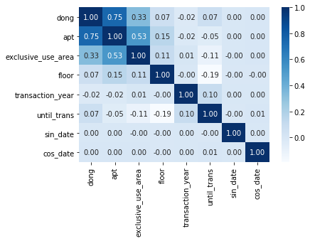

```python
corr_plot = sns.heatmap(corr,annot = True,  fmt = '.2f', cbar = True, cmap = 'Blues')
```

<해석>

우선, 상관계수 플랏을 보자마자 느낄 수 있는 것은 일부를 제외한(apt와 동) 변수들 간에는 상관관계가 거의 존재하지 않는다고 보는게 타당하다는 것이다. Ridge 회귀의 식을 보면 회귀계수의 제곱에 alpha 값으로 제약을 주는 모양이다. 이는 가중치의 절대값을 작게 해서 과대 적합이 되지 않게 제약을 거는 것인데, 이러한 특성은 결국 변수 간 상관관계가 높은 모델에서 더 잘 예측하는 결과로 이어진다. 정리하자면 Ridge 회귀는 변수간 상관관계가 높은 상황에서 Lasso 회귀보다 좋은 성능을 내는 게 장점이지만, 위와 같은 상황에서는 변수간 상관관계가 매우 낮으므로 적절하다고 생각되지 않는다.

## 2.2 해석과 무관하게 일단 릿지 튜닝

```python
from sklearn.linear_model import Ridge
from sklearn.metrics import mean_squared_error
from math import sqrt
```

```python
alpha_value = 0.000001
ridge_list = []
for i in range(5) :
    alpha_value *= 10
    ridge = Ridge(alpha = alpha_value)
    ridge.fit(train_cbe, Y_train)
    ridge_list.append(ridge)
```

```python
rmse_list = []
predict_list = []
for ridge in ridge_list :
    pred = ridge.predict(val_cbe)
    predict_list.append(pred)
    mse = mean_squared_error(Y_val,pred)
    rmse = sqrt(mse)
    rmse_list.append(rmse)
```

```python
num = 0.000001
for rmse in rmse_list :
    num *= 10
    print("alpha가 %.5f일 때 rmse 값 : %f"%(num,rmse))
```

```
alpha가 0.00001일 때 rmse 값 : 15377.977659
alpha가 0.00010일 때 rmse 값 : 15377.977659
alpha가 0.00100일 때 rmse 값 : 15377.977661
alpha가 0.01000일 때 rmse 값 : 15377.977679
alpha가 0.10000일 때 rmse 값 : 15377.977855
```

## 2.3 튜닝결과 시각화

우선, 어떤식으로 예측이 되었는지 궁금해서 다음과 같은 plot을 그려보았다.

```python
def plot_predictions(name_, pred, actual):
    df = pd.DataFrame({'prediction': pred, 'actual': actual})
    df = df.sort_values(by='actual').reset_index(drop=True)

    plt.figure(figsize=(8, 7))
    plt.scatter(df.index, df['prediction'], marker='x', color='r')
    plt.scatter(df.index, df['actual'], alpha=0.7, marker='o', color='black')
    plt.title(name_, fontsize=15)
    plt.legend(['prediction', 'actual'], fontsize=12)
    plt.show()

def mse_eval(name_, pred, actual):
    global my_predictions, colors, my_pred, my_actual, my_name

    colors = ['r', 'c', 'm', 'y', 'k', 'khaki', 'teal', 'orchid', 'sandybrown',
          'greenyellow', 'dodgerblue', 'deepskyblue', 'rosybrown', 'firebrick',
          'deeppink', 'crimson', 'salmon', 'darkred', 'olivedrab', 'olive',
          'forestgreen', 'royalblue', 'indigo', 'navy', 'mediumpurple', 'chocolate',
          'gold', 'darkorange', 'seagreen', 'turquoise', 'steelblue', 'slategray',
          'peru', 'midnightblue', 'slateblue', 'dimgray', 'cadetblue', 'tomato'
         ]

    my_predictions = {}
    my_name = name_
    my_pred = pred
    my_actual = actual

    plot_predictions(name_, pred, actual)

    mse = mean_squared_error(pred, actual)
    my_predictions[name_] = mse

    y_value = sorted(my_predictions.items(), key=lambda x: x[1], reverse=True)

    df = pd.DataFrame(y_value, columns=['model', 'mse'])
    print(df)
    min_ = df['mse'].min() - 10
    max_ = df['mse'].max() + 10

    length = len(df) / 2

    plt.figure(figsize=(9, length))
    ax = plt.subplot()
    ax.set_yticks(np.arange(len(df)))
    ax.set_yticklabels(df['model'], fontsize=12)
    bars = ax.barh(np.arange(len(df)), df['mse'], height=0.3)

    for i, v in enumerate(df['mse']):
        idx = np.random.choice(len(colors))
        bars[i].set_color(colors[idx])
        ax.text(v + 2, i, str(round(v, 3)), color='k', fontsize=12, fontweight='bold', verticalalignment='center')

    plt.title('MSE Error', fontsize=16)
    plt.xlim(min_, max_)

    plt.show()
```

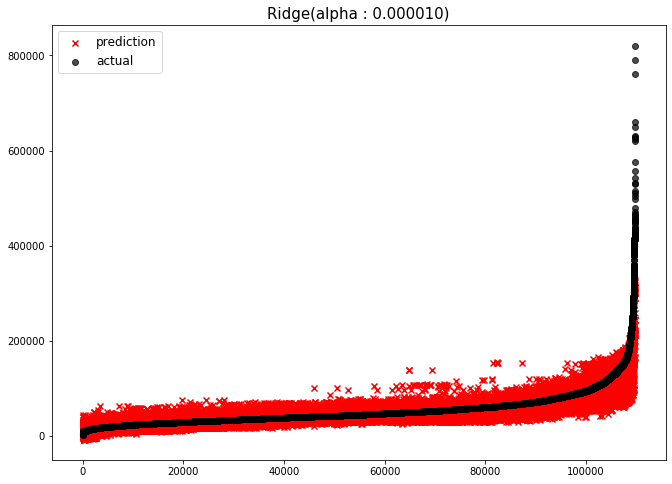

```
                     model           mse
0  Ridge(alpha : 0.000010)  2.364822e+08
```

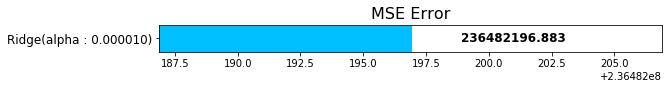

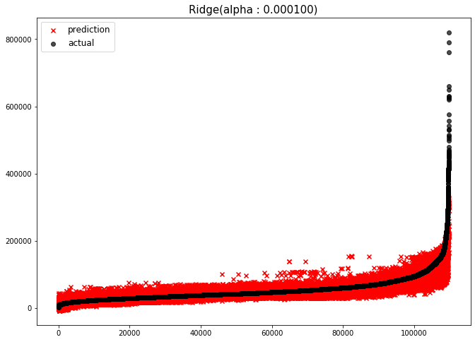

```
                     model           mse
0  Ridge(alpha : 0.000100)  2.364822e+08
```

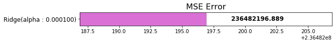

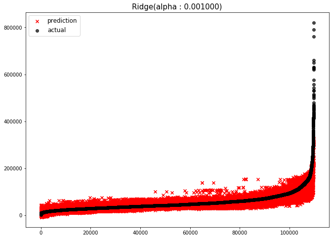

```
                     model           mse
0  Ridge(alpha : 0.001000)  2.364822e+08
```

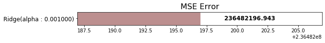

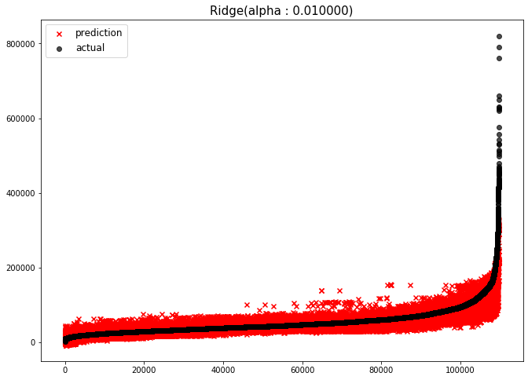

```
                     model           mse
0  Ridge(alpha : 0.010000)  2.364822e+08
```

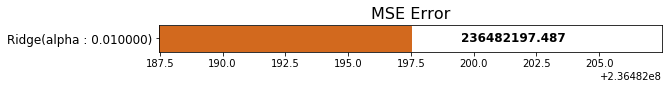

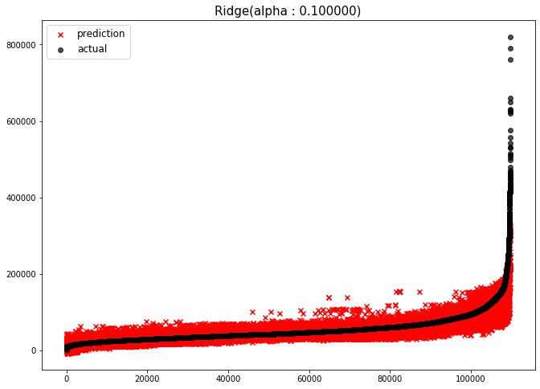

```
                     model           mse
0  Ridge(alpha : 0.100000)  2.364822e+08
```

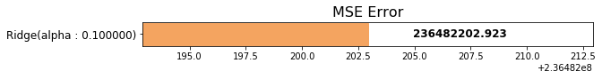

```python
alpha_to_plot = {0.00001 : 231 ,0.0001 : 232, 0.001 : 233 ,0.01 : 234 ,0.1 : 235}

num = 0

for alpha in alpha_to_plot.keys() :
    mse_eval('Ridge(alpha : %f)'%alpha, predict_list[num], Y_val)
    num += 1
```

RMSE값은 기본 단위가 높아서이기도 하지만, 이상치들이 매우 많이 존재하고 그 값들이 모두 매우 큰 값들이므로 일어나는 현상이기도 하다는 것을 확인

## 2.4 해석

튜닝이 잘 안된 것 같다. 파라미터에 따른 값 차이가 거의 존재하지 않는다.

그 이유는 ridge 회귀의 수식에서 볼 수 있듯이 ridge의 alpha는 베타계수에 제약을 거는 역할을 하며, 이는 상관관계가 다소 높은 모델에서 효율적인 튜닝을 보여준다. 하지만 우리 모델은 위에서 확인한 바와 같이 상관관계가 적은 모델이므로 다른 회귀에 비해 성능이 떨어진다고 평가할 수 있다.

또한, ridge의 alpha 값이 베타계수에 제한(제약)을 걸 때, x값의 단위가 높으면 이는 제한을 걸어서 그 값을 낮추기 위해 매우 작은 alpha값을 필요로 하게 되고, alpha값이 작아짐에 따라 성능의 효율이 감소하게 된다. 예를 들어 alpha가 극단적으로 0으로 가게되면, 이는 일반 선형 회귀랑 다를게 없어진다는 것을 생각했을 때 납득하기 쉬울 것 같다.

## 2.5 그냥 선형 모형

```python
from sklearn.linear_model import LinearRegression
```

```python
lr = LinearRegression()
lr.fit(train_cbe,Y_train)
y_preds = lr.predict(val_cbe)
mse = mean_squared_error(Y_val, y_preds)
rmse = sqrt(mse)
print("ridge : %f, linear : %f"%(np.mean(rmse_list),rmse))
```

```
ridge : 15377.977703, linear : 15377.977659
```

거의 차이가 없다.

# 3. LightGBM

## 3.1 LightGBM 이해

LGBM의 특징 : 일반 GBM 계열의 트리 분할 방법과 다르게 리프 중심 트리 분할 방식을 사용한다. 이 방식은 트리의 균형을 맞추지는 않고, 최대 손실 값을 가지는 리프 노드를 지속적으로 분할하면서 트리의 깊이가 깊어지고 비대칭적인 규칙 트리가 생성된다. 이렇게 최대 손실값을 가지는 리프 노드를 지속적으로 분할해 생성된 규칙 트리는 학습을 반복할수록 결국 균형 트리 분할 방식보다 예측 오류 손실을 최소화 할 수 있다고 생각한 것이 LGBM의 구현 사상이다.

장점 : 학습에 걸리는 시간이 적은 편이고, 메모리 사용량도 적은 편이다. 그러면서도 예측 성능이 XGBoost와 크게 차이나지 않는다. 오히려 기능상 다양성은 LGBM이 더 많은 편이다. 이는 LGBM이 XGBoost의 단점을 보완하고 장점을 계승해서 개발되었기 때문이다.

문제점 : 적은 데이터 세트를 적용할 경우 과적합이 발생하기 쉽다.

## 3.2 LGBM 튜닝

```python
import lightgbm as lgb
from lightgbm import LGBMModel,LGBMRegressor
```

```python
lgb_dict = {}
learning_rate_list = [0.01,0.05,0.1,0.3,0.5,0.7,0.99]
for rate in learning_rate_list :
    lgb_model = LGBMRegressor(learning_rate = rate)
    lgb_model.fit(train_cbe,Y_train)
    pred = lgb_model.predict(val_cbe, num_iteration= lgb_model.best_iteration_)

    mse = mean_squared_error(Y_val, pred)
    rmse = sqrt(mse)

    lgb_dict['rate '+str(rate)] = rmse
```

```python
lgbm_df = pd.DataFrame({'rate' : list(lgb_dict.keys()),
             'rmse' : list(lgb_dict.values())})
lgbm_df
```

|  | rate | rmse |
| --- | --- | --- |
| 0 | rate 0.01 | 20688.401326 |
| 1 | rate 0.05 | 11209.651027 |
| 2 | rate 0.1 | 10340.974690 |
| 3 | rate 0.3 | 9725.425114 |
| 4 | rate 0.5 | 9431.094372 |
| 5 | rate 0.7 | 9726.414218 |
| 6 | rate 0.99 | 10501.177372 |

learning_rate가 0.5일 때 가장 값이 작다.

### 3.3 튜닝결과 시각화

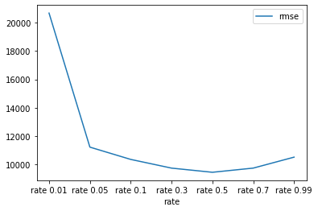

```python
lgbm_df.set_index('rate').plot()
```

### 3.4 튜닝에 대해 알아보기

Grid Search : 하이퍼 파라미터의 후보군들을 직접 선택해서 집어넣는다. 장점으로는 사용자가 지정한 파라미터들의 결과를 알려준다는 점과 나름 균등하고 전역적 탐색이 가능하다는 점이 있지만, 단점으로는 파라미터 수가 증가하고 후보군의 개수가 증가하면 전체 탐색기간이 매우 길어진다는 점이 있다.

Random Search : 하이퍼 파라미터의 값의 범위를 선택하면, 그 안에서 임의의 수를 선택해서 탐색한다. 범위 안에서 무작위로 조합을 만들어서 에러가 작은 쪽으로 찾아가는 방식이다. 장점으로는 시간이 절약되어서 그리드 서치보다 파라미터 수가 많을 때 이용한다.

Baysian Optimization : 사전에 선택된 파라미터를 반영하여 탐색한다. 매 시도에 새로운 파라미터 값에 대한 조사 수행을 할 때 사전지식을 충분히 반영하면서 전체적인 탐색 과정을 체계적으로 수행하기 위해 고려해볼 수 있는 방법이다. 따라서, 장점으로는 Grid Search와 Random Search이 사전지식을 고려하지 않는 다는 점에 비해 이 방법은 사전지식을 고려한다는 점이 있다.

# 4. test set

### 4.1 test set 불러오기

```python
#test set은 1번에서 불러옴 : test_df
test_X = test_df.drop('price', axis = 1)
test_Y = test_df['price']
```

### 4.2 캣부스트 인코딩

```python
cbe_encoder = CatBoostEncoder() # 객체생성 후 학습
cbe_encoder.fit(train_X,train_Y) # 전체 train set에 대해서 학습
```

```
CatBoostEncoder(a=1, cols=['dong', 'apt'], drop_invariant=False,
                handle_missing='value', handle_unknown='value',
                random_state=None, return_df=True, sigma=None, verbose=0)
```

```python
train_cbe = cbe_encoder.transform(train_X)
test_cbe = cbe_encoder.transform(test_X)  # test set에 적용
```

```python
test_cbe.head()
```

|  | dong | apt | exclusive_use_area | floor | transaction_year | until_trans | sin_date | cos_date |
| --- | --- | --- | --- | --- | --- | --- | --- | --- |
| 0 | 91827.227742 | 89369.051084 | 70.80 | 1 | 5 | 10 | -1.000000e+00 | -1.836970e-16 |
| 1 | 91827.227742 | 89369.051084 | 94.51 | 8 | 5 | 10 | -2.449294e-16 | 1.000000e+00 |
| 2 | 91827.227742 | 89369.051084 | 160.85 | 11 | 5 | 10 | -2.449294e-16 | 1.000000e+00 |
| 3 | 91827.227742 | 89369.051084 | 94.51 | 6 | 5 | 10 | 1.000000e+00 | 3.061617e-16 |
| 4 | 91827.227742 | 89369.051084 | 136.40 | 3 | 5 | 10 | 1.000000e+00 | 3.061617e-16 |

### 4.3 최적의 파라미터 적합

```python
# Ridge Regression

ridge = Ridge(alpha = 0.00001) # 그나마 rmse가 적은 0.00001 선택
ridge.fit(train_cbe, train_Y)

# LightGBM

lgb_model = LGBMRegressor(learning_rate = 0.5) # 최적의 파라미터 0.5 선택
lgb_model.fit(train_cbe,train_Y)
```

```
LGBMRegressor(boosting_type='gbdt', class_weight=None, colsample_bytree=1.0,
              importance_type='split', learning_rate=0.5, max_depth=-1,
              min_child_samples=20, min_child_weight=0.001, min_split_gain=0.0,
              n_estimators=100, n_jobs=-1, num_leaves=31, objective=None,
              random_state=None, reg_alpha=0.0, reg_lambda=0.0, silent=True,
              subsample=1.0, subsample_for_bin=200000, subsample_freq=0)
```

### 4.4 test set에 대해 평가

```python
# Ridge Regression

pred_ridge = ridge.predict(test_cbe)
mse_ridge = mean_squared_error(test_Y,pred_ridge)
rmse_ridge = sqrt(mse_ridge)

# LightGBM

pred_lgb = lgb_model.predict(test_cbe)
mse_lgb = mean_squared_error(test_Y, pred_lgb)
rmse_lgb = sqrt(mse_lgb)


print("Ridge : %f, LightGBM : %f"%(rmse_ridge, rmse_lgb))
```

```
Ridge : 17721.880605, LightGBM : 11909.118492
```

정리하자면, RMSE값을 미루어 보아 해당 모델에서는 LightGBM의 성능이 더 좋게 나왔다고 평가할 수 있다.